# Modeling workflow

Author

Victor Van der Meersch

Published

April 2025

```r
library(ape)
library(geiger)
library(phytools)
require(rstan)
library(future)
library(future.apply)

kippenberger <- c("#8B174DFF", "#AE2565FF", "#C1447EFF", "#D06C9BFF", "#DA9FB8FF",
                  "#ADBE7CFF", "#8BA749FF", "#6E8537FF", "#4F5F28FF", "#343D1FFF")
```

## 1 Conceptual analysis

As a first step, I think the main question we’re trying to answer is:  
➡ What are the germination responses to different cues? (see [GitHub repo wiki](https://github.com/lizzieinvancouver/egret/wiki/Questions))

To answer this question, a systematic review of the scientific literature was conducted, focusing on controlled germination trials. They discarded:

- studies on crops ( with likely altered traits because of active anthropogenic selection)
- studies conducted in the field (not fully controlled environments)
- studies with treatments not clearly distinguishable
- … and other criteria I don’t know about …

To begin with, we focus solely on the effects of chilling (stratification) and forcing on germination.

## 2 Model building

### 2.1 Simulate seed counts

Let’s simulate some data! We assume a priori that species are related through a given phylogenetic tree (so we start from a quite complex model…), with a certain total length $\phi$.  
The following block of code is largely inspired from Deirdre’s amazing work for OSPREE.

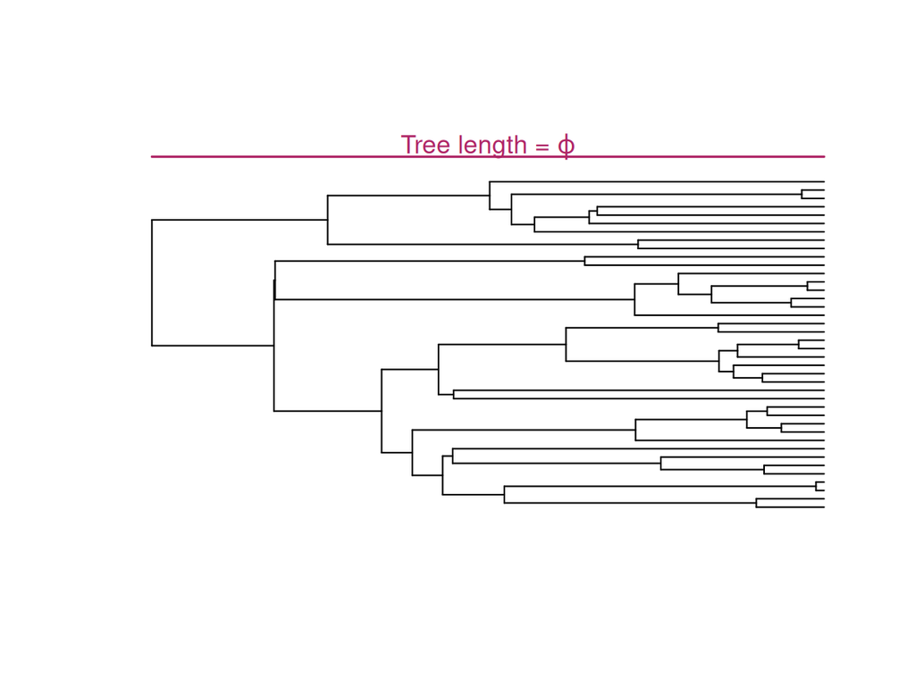

```r
nspecies <- 40 # let's say we have 40 species

# stochastic birth-death trees (from Deirdre)
maxlength <- runif(1,10,20)
spetree <- pbtree(n=nspecies, nsim=1, b=1, complete=FALSE,scale=maxlength, type = "continuous")
# with a total length bewteen 10 and 20 (scale = maxlength)
# note: we could set a length = 1, but we want to avoid any confusion
# between the covariance matrix [vcv(spetree, corr = FALSE)]
# and the correlation matrix [vcv(spetree, corr = TRUE)]...

spetree$tip.label <- paste("s", 1:nspecies, sep="")
palette <- colorRampPalette(kippenberger)(nspecies)


plot(spetree, show.tip.label = FALSE, y.lim = c(0,45), x.lim = c(0,maxlength))
segments(x0 = 0, y0 = 43, x1 = maxlength, col = "#AE2565FF", lwd=1.5)
text(x = maxlength/2, y = 44.2, label = expression(paste("Tree length = ", varphi)), cex = 1,  col = "#AE2565FF")
```

We thus make the hypothesis that the correlation (or covariance) between the species is a function of their relative distance (in the phylogenetic tree), $\Delta x = | x_{sp_i} - x_{sp_j} |$.  
The maximum distance between two species is thus $\max\Delta x = 2 * \phi$.  
We can then visualize the structure of the covariance function, either with a covariogram or with a correlogram (see [Mike’s chapter on Gaussian Processes](https://betanalpha.github.io/assets/case_studies/gaussian_processes.html)).

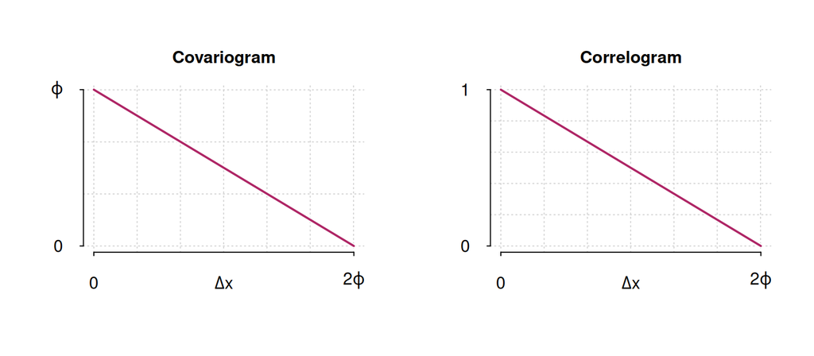

```r
# distance between species
distance <- cophenetic(spetree)
# round(max(distance),2) == round(2 * maxlength,2)

# phylo covariance matrix
covariance_matrix <- vcv(spetree, corr = FALSE)
correlation_matrix <- vcv(spetree, corr = TRUE)

dataplot <- unique(data.frame(
  dist = c(distance),
  cov = c(covariance_matrix),
  corr = c(correlation_matrix)
))

par(mfrow = c(1,2))

plot.new()
plot.window(xlim = c(0,max(distance)), ylim = c(0,maxlength))
grid()
axis(1, las = 1, cex.axis = 1, tck=-0.02, at = c(0,max(distance)), labels=c("0", expression(paste("2", varphi))))
axis(2, las = 1, cex.axis = 1, tck=-0.02, at = c(0,maxlength), labels=c("0", expression(paste(varphi))))
title(main = "Covariogram", xlab = expression(paste(Delta,x)),  line=1, cex.main = 1)
lines(dataplot$dist, dataplot$cov, col="white", lwd=4)
lines(dataplot$dist, dataplot$cov, col="#AE2565FF", lwd=2)

plot.new()
plot.window(xlim = c(0,max(distance)), ylim = c(0,1))
grid()
axis(1, las = 1, cex.axis = 1, tck=-0.02, at = c(0,max(distance)), labels=c("0", expression(paste("2", varphi))))
axis(2, las = 1, cex.axis = 1, tck=-0.02, at = c(0,1), labels=c("0", "1"))
title(main = "Correlogram", xlab = expression(paste(Delta,x)),  line=1, cex.main = 1)
lines(dataplot$dist, dataplot$corr, col="white", lwd=4)
lines(dataplot$dist, dataplot$corr, col="#AE2565FF", lwd=2)
```

```r
lambda <- 0.7
corr_pagel <- lambda * covariance_matrix
corr_pagel <- corr_pagel - diag(diag(corr_pagel)) + diag(diag(covariance_matrix))
```

So, the way we simulate data assume a linear relationship between the relative distance $\Delta x$ between species and their expected covariance:
$$f(\Delta x) = \phi - \frac{\Delta x}{2}$$
When accounting for the Pagel’s $\lambda$, we introduce a discontinuity:

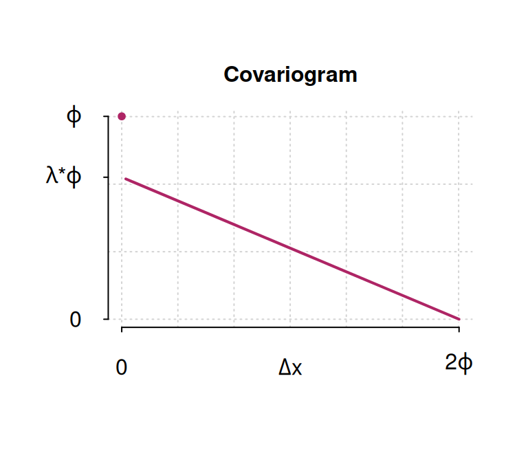

```r
lambda <- 0.7 # as an example

cov_pagel <- lambda * covariance_matrix
cov_pagel <- corr_pagel - diag(diag(corr_pagel)) + diag(diag(covariance_matrix))

dataplot <- unique(data.frame(
  dist = round(c(distance),2),
  cov = round(c(cov_pagel),2)
))

dataplot_sub <- dataplot[dataplot$dist != 0,]

par(mfrow = c(1,1))

plot.new()
plot.window(xlim = c(0,max(distance)), ylim = c(0,maxlength))
grid()
axis(1, las = 1, cex.axis = 1, tck=-0.02, at = c(0,max(distance)), labels=c("0", expression(paste("2", varphi))))
axis(2, las = 1, cex.axis = 1, tck=-0.02, at = c(0,lambda*maxlength,maxlength), labels=c("0", expression(paste(lambda, "*", varphi)), expression(paste(varphi))))
title(main = "Covariogram", xlab = expression(paste(Delta,x)),  line=1, cex.main = 1)
lines(dataplot_sub$dist, dataplot_sub$cov, col="white", lwd=4)
lines(dataplot_sub$dist, dataplot_sub$cov, col="#AE2565FF", lwd=2)
points(dataplot[dataplot$dist == 0, "dist"], dataplot[dataplot$dist == 0, "cov"],
       col="#AE2565FF", pch = 20)
```

The data generating process is, by nature, binomial: starting from a known number of seeds, we observe the number of successes (seeds that germinate).  
For convenience, we create a function to simulate from a binomial distribution. We consider only one covariate.

```r
simulate_data_improved <- function(spetree){

  # parameters
  params <- list(a_z = rnorm(1,0,1.5), # root value intercept
                 lambda_a = rbeta(1,1.5,1.5), # lambda intercept
                 sigma_a = abs(rnorm(1,0,1)), # rate of evolution intercept
                 b_z = rnorm(1,0.5,1), # root value trait1 slope
                 lambda_b = rbeta(1,1.5,1.5), # lambda trait1
                 sigma_b = abs(rnorm(1,0,1)) # rate of evolution trait1
  )

  ## Simulate some data ##
  # phylogenetic structure (from Deirdre)
  scaledtree_intercept <- rescale(spetree, model = "lambda", params$lambda_a)
  params$intercepts <- fastBM(scaledtree_intercept,
                              a = params$a_z, mu = 0,
                              sig2 = params$sigma_a ^ 2)
  scaledtree_slope <- rescale(spetree, model = "lambda", params$lambda_b)
  params$slopes <- fastBM(scaledtree_slope,
                          a = params$b_z, mu = 0,
                          sig2 = params$sigma_b ^ 2)

  # We consider that a study looks only  at one species
  # and that a species might be considered by several studies
  nstudies_perspecies <- round(runif(nspecies, 1, 3)) # no. of different studies per species
  nstudies <- sum(nstudies_perspecies) # total number of studies
  species_study <- rep(1:nspecies, times = nstudies_perspecies) # species id considered by each study
  ntreat_perstudies <- round(runif(nstudies, 2, 6)) # no. of different treatments applied per study
  nexps <- sum(ntreat_perstudies) # total no. of experiments (i.e. studies*treatments)
  ntrialseeds_perexp <- round(runif(nexps, 10, 100)) # no. of seeds per experiments
  studies <- rep(1:nstudies, times = ntreat_perstudies)
  species <- rep(species_study, times = ntreat_perstudies) # species id per experiments

  # experimental observations
  x <- rnorm(n = nexps, mean = 0, sd = 1) # treatments applied
  yhat <- plogis(params$intercepts[species] + x * params$slopes[species],
                 location = 0, scale = 1)
  y = rbinom(n = nexps, size = ntrialseeds_perexp, prob = yhat)

  return(list(
    params = lapply(params,round,2),
    data = data.frame(species, studies, nseeds = ntrialseeds_perexp, x, y),
    vphy = vcv(spetree, corr = TRUE)))

}
```

We can then easily simulate many different datasets! And plot them.

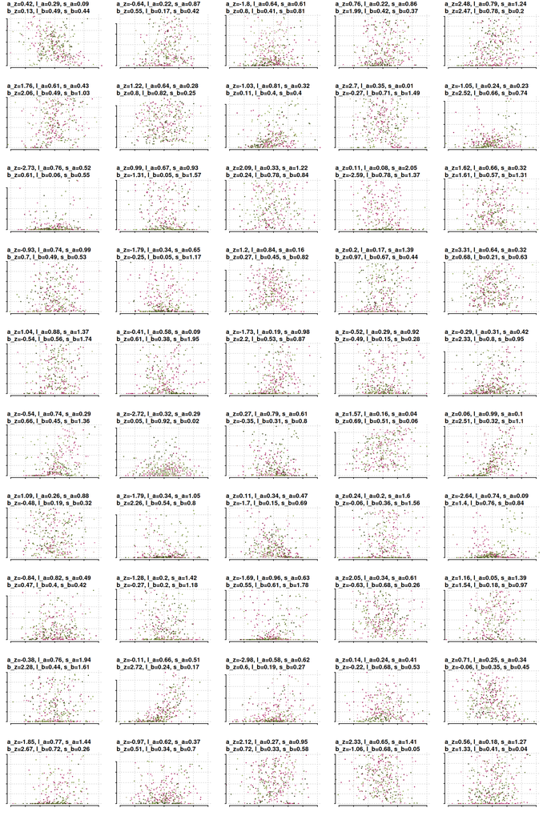

```r
nsets <- 50
simulated_data <- lapply(1:nsets, function(i){
  simulate_data_improved(spetree)
})

par(mfrow = c(10,5), mar=c(1,0,1,0)+1)
for(i in 1:nsets){

  plot.new()
  plot.window(xlim = c(-3,3), ylim = c(0,max(simulated_data[[i]]$data$y)))
  grid()
  points(x = simulated_data[[i]]$data$x, y =  simulated_data[[i]]$data$y,
         pch = 19, cex = 0.2,
         col = palette[simulated_data[[i]]$data$sp])
  axis(1, las = 1, cex.axis = 0.7, tck=-0.02, labels=FALSE)
  axis(2, las = 2, cex.axis = 0.7, tck=-0.02, labels=FALSE)
  title(paste0("a_z=", simulated_data[[i]]$params$a_z, ", l_a=", simulated_data[[i]]$params$lambda_a, ", s_a=", simulated_data[[i]]$params$sigma_a, "\n",
               "b_z=", simulated_data[[i]]$params$b_z, ", l_b=", simulated_data[[i]]$params$lambda_b, ", s_b=", simulated_data[[i]]$params$sigma_b),
        adj=0, cex.main = 1)


}
```

### 2.2 Binomial likelihood

In an ideal situation, we would always have the total number of seeds (number of trials) that each study is using.  
We could then use a binomial likelihood.

```stan
data {

  int<lower=1> N;
  int<lower=1> Nsp;
  int<lower=1, upper=Nsp> sp[N];
  int<lower=1> Ntrials[N];
  int<lower=0> y[N]; // response, number of successes!
  vector[N] x; // predictor
  corr_matrix[Nsp] Vphy; // phylogenetic relationship matrix (fixed)

}

parameters {

  // intercept (+ the portion of phenotypes, not predicted by x, which still covary between related species, right?)
  vector[Nsp] a;
  real a_z; // root value
  real<lower=0, upper=1> lambda_a; // phylogenetic structure
  real<lower=0> sigma_a; // overall rate of change (brownian motion?)

  // slope of x effect
  vector[Nsp] b;
  real b_z; // root value
  real<lower=0, upper=1> lambda_b;  // phylogenetic structure
  real<lower=0> sigma_b; // overall rate of change (brownian motion?)

}

transformed parameters{

  corr_matrix[Nsp] C_a = lambda_a * Vphy;
  C_a = C_a - diag_matrix(diagonal(C_a)) + diag_matrix(diagonal(Vphy));

  corr_matrix[Nsp] C_b = lambda_b * Vphy;
  C_b = C_b - diag_matrix(diagonal(C_b)) + diag_matrix(diagonal(Vphy));

  // more numerically stable and more efficient to use pre-factored covariance matrices (i.e. multi_normal_cholesky in the following
  matrix[Nsp,Nsp] L_a = cholesky_decompose(sigma_a^2*C_a);
  matrix[Nsp,Nsp] L_b =  cholesky_decompose(sigma_b^2*C_b);
  real<lower=0, upper = 1> mu[N];

  for(i in 1:N){
    mu[i] = inv_logit(a[sp[i]] + b[sp[i]] * x[i]);
  }

}

model {

  a ~ multi_normal_cholesky(rep_vector(a_z,Nsp), L_a);
  b ~ multi_normal_cholesky(rep_vector(b_z,Nsp), L_b);

  // y ~ beta(shape_alpha, shape_beta);
  y ~ binomial(Ntrials, mu);

  // priors
  a_z ~ normal(0, 1.5);
  b_z ~ normal(0.5, 1);

  lambda_a ~ beta(1.5, 1.5);
  sigma_a ~ normal(0, 1);

  lambda_b ~ beta(1.5, 1.5);
  sigma_b ~ normal(0, 1);

}
```

### 2.3 Beta likelihood

But we rarely have the initial number of seeds, so we will need to use *percentage of germination* rather than number of successes/number of trials.  
So we will likely need a Beta likelihood. As the support of a Beta distribution does not include 0 and 1, we implement a ordered Beta regression (following [R. Kubinec work](https://doi.org/10.1017/pan.2022.20)):

```stan
// Beta regression with proportion and degenerate responses (i.e. 0 and 1)
// Original code from R. Kubinec, https://github.com/saudiwin/ordbetareg

functions {

  // prior from Michael Betancourt for ordered cutpoints
  // see: https://betanalpha.github.io/assets/case_studies/ordinal_regression.html
    real induced_dirichlet_lpdf(vector c, vector alpha, real phi) {
    int K = num_elements(c) + 1;
    vector[K - 1] sigma = inv_logit(phi - c);
    vector[K] p;
    matrix[K, K] J = rep_matrix(0, K, K);

    // Induced ordinal probabilities
    p[1] = 1 - sigma[1];
    for (k in 2:(K - 1))
      p[k] = sigma[k - 1] - sigma[k];
    p[K] = sigma[K - 1];

    // Baseline column of Jacobian
    for (k in 1:K) J[k, 1] = 1;

    // Diagonal entries of Jacobian
    for (k in 2:K) {
      real rho = sigma[k - 1] * (1 - sigma[k - 1]);
      J[k, k] = - rho;
      J[k - 1, k] = rho;
    }

    return   dirichlet_lpdf(p | alpha)
           + log_determinant(J);
  }
}

data {

  int<lower=0> N_prop; // number of proportion observations (0,1)
  int<lower=0> N_degen; // number of 0/1 observations

  int<lower=1> Nsp; // number of species
  int<lower=1, upper=Nsp> sp_prop[N_prop]; // species ID for prop. observations
  int<lower=1, upper=Nsp> sp_degen[N_degen]; // species ID for degen. observations

  vector[N_prop] y_prop; // Y in (0,1)
  int<lower=0,upper = 1> y_degen[N_degen]; // Y in {0,1}

  vector[N_prop] x_prop; // covariate X for proportion outcome
  vector[N_degen] x_degen; // covariate X for degenerate (0,1) outcome

  corr_matrix[Nsp] Vphy; // phylogenetic relationship matrix (fixed)
}

parameters {

  // intercept (+ the portion of phenotypes, not predicted by x, which still covary between related species, right?)
  vector[Nsp] a;
  real a_z; // root value
  real<lower=0, upper=1> lambda_a; // phylogenetic structure
  real<lower=0> sigma_a; // overall rate of change (brownian motion?)

  // slope of x effect
  vector[Nsp] b;
  real b_z; // root value
  real<lower=0, upper=1> lambda_b;  // phylogenetic structure
  real<lower=0> sigma_b; // overall rate of change (brownian motion?)

  ordered[2] cutpoints; // cutpoints on ordered (latent) variable (also stand in as intercepts)
  real<lower=0> kappa; // scale parameter for beta regression
}

transformed parameters {

  corr_matrix[Nsp] C_a = lambda_a * Vphy;
  C_a = C_a - diag_matrix(diagonal(C_a)) + diag_matrix(diagonal(Vphy));

  corr_matrix[Nsp] C_b = lambda_b * Vphy;
  C_b = C_b - diag_matrix(diagonal(C_b)) + diag_matrix(diagonal(Vphy));

  // more numerically stable and more efficient to use pre-factored covariance matrices (i.e. multi_normal_cholesky in the following
  matrix[Nsp,Nsp] L_a = cholesky_decompose(sigma_a^2*C_a);
  matrix[Nsp,Nsp] L_b =  cholesky_decompose(sigma_b^2*C_b);

  real calc_degen[N_degen];
  real calc_prop[N_prop];

  if(N_degen>0) {
    for(i in 1:N_degen){
      calc_degen[i] = a[sp_degen[i]] + b[sp_degen[i]] * x_degen[i];
    }
  }

  for(i in 1:N_prop){

    calc_prop[i] = a[sp_prop[i]] + b[sp_prop[i]] * x_prop[i];

  }

}
model {

  a ~ multi_normal_cholesky(rep_vector(a_z,Nsp), L_a);
  b ~ multi_normal_cholesky(rep_vector(b_z,Nsp), L_b);

  target += induced_dirichlet_lpdf(cutpoints | rep_vector(1, 3), 0);

  // need separate loops for logit (0/1) and beta regression
  if(N_degen>0) {
    for(n in 1:N_degen) {
      if(y_degen[n]==0) {
        // Pr(Y==0)
        target += log1m_inv_logit(calc_degen[n] - cutpoints[1]);
      } else {
        //Pr(Y==1)
        target += log_inv_logit(calc_degen[n] - cutpoints[2]);
      }
    }
  }

  for(n in 1:N_prop) {
    // Pr(Y in (0,1))
    target += log(inv_logit(calc_prop[n] - cutpoints[1]) - inv_logit(calc_prop[n] - cutpoints[2]));
    // Pr(Y==x where x in (0,1))
    y_prop[n] ~ beta_proportion(inv_logit(calc_prop[n]),kappa);
  }

  // priors
  a_z ~ normal(0, 1.5);
  b_z ~ normal(0.5, 1);

  lambda_a ~ beta(1.5, 1.5);
  sigma_a ~ normal(0, 1);

  lambda_b ~ beta(1.5, 1.5);
  sigma_b ~ normal(0, 1);

  kappa ~ exponential(.1); // vague?

}
```

### 2.4 Compare both models

Let’s fit both models on the simulated datasets.

```r
get_estimates <- function(summ){
  return(
    data.frame(lambda_a.mean = summ["lambda_a" , "mean"],
             lambda_a.q2.5 = summ["lambda_a" , "X2.5."],
             lambda_a.q97.5  = summ["lambda_a" , "X97.5."],
             sigma_a.mean = summ["sigma_a" , "mean"],
             sigma_a.q2.5 = summ["sigma_a" , "X2.5."],
             sigma_a.q97.5  = summ["sigma_a" , "X97.5."],
             lambda_b.mean = summ["lambda_b" , "mean"],
             lambda_b.q2.5 = summ["lambda_b" , "X2.5."],
             lambda_b.q97.5  = summ["lambda_b" , "X97.5."],
             sigma_b.mean = summ["sigma_b" , "mean"],
             sigma_b.q2.5 = summ["sigma_b" , "X2.5."],
             sigma_b.q97.5  = summ["sigma_b" , "X97.5."],
             slopes.mean = summ[paste0("b[", 1:nspecies, "]"), "mean"],
             slopes.q2.5 = summ[paste0("b[", 1:nspecies, "]"), "X2.5."],
             slopes.q97.5 = summ[paste0("b[", 1:nspecies, "]"), "X97.5."],
             intercepts.mean = summ[paste0("a[", 1:nspecies, "]"), "mean"],
             intercepts.q2.5 = summ[paste0("a[", 1:nspecies, "]"), "X2.5."],
             intercepts.q97.5 = summ[paste0("a[", 1:nspecies, "]"), "X97.5."],
             a_z.mean = summ["a_z", "mean"],
             a_z.q2.5 = summ["a_z", "X2.5."],
             a_z.q97.5 = summ["a_z", "X97.5."],
             b_z.mean = summ["b_z", "mean"],
             b_z.q2.5 = summ["b_z", "X2.5."],
             b_z.q97.5 = summ["b_z", "X97.5."]))
}


run_models <- FALSE

# fit models
if(run_models){

  smbin <- stan_model("../stan/binomiallikelihood.stan")
  plan(multisession, workers = 4) # here we use 4x4 = 16 cores (i.e. nested parallelization)
  databin <- future_lapply(simulated_data, function(simulated){

      mdl.data <- list(y = simulated$data$y,
                       N = nrow(simulated$data),
                       Nsp = nspecies,
                       sp = simulated$data$species,
                       x = simulated$data$x,
                       Ntrials = simulated$data$nseeds,
                       Vphy= simulated$vphy)

      fit <- sampling(smbin, mdl.data,
                      iter = 4000, warmup = 3000,
                      chains = 4, cores = 4)

      summ <- data.frame(summary(fit)[["summary"]])

      sampler_params  <- get_sampler_params(fit, inc_warmup = FALSE)
      diagnostics <- list(
        max_treedepth= max(sapply(sampler_params, function(x) max(x[, "treedepth__"]))),
        max_divergence = max(sapply(sampler_params, function(x) sum(x[, "divergent__"]))),
        max_rhat = max(summ$Rhat, na.rm = TRUE),
        min_ess = min(summ$n_eff, na.rm = TRUE)
      )

      estimates <- get_estimates(summ)

      posteriors <- c(extract(fit, pars = c("lambda_a", "lambda_b")), chain = list(rep(1:4, each = 1000)), limits = list(c(0,1)))

      return(list(sim = simulated$data,
                  est = estimates,
                  post = posteriors,
                  par = simulated$params,
                  diag = diagnostics))
    }, future.seed=TRUE)
  plan(sequential);gc()
  saveRDS(databin, file = "output/comparison/bionomiallikelihood.rds")

  smordbeta <- stan_model("../stan/orderedbetalikelihood.stan")
  plan(multisession, workers = 4)
  databeta <- future_lapply(simulated_data, function(simulated){

      simulated$data$yperc <- simulated$data$y/simulated$data$nseeds

      mdl.data <- list(N_degen=sum(simulated$data$yperc %in% c(0,1)),
                       N_prop=sum(simulated$data$yperc>0 & simulated$data$yperc<1),

                       Nsp = nspecies,
                       sp_degen = array(simulated$data$species[simulated$data$yperc %in% c(0,1)],
                                        dim = sum(simulated$data$yperc %in% c(0,1))),
                       sp_prop = simulated$data$species[simulated$data$yperc>0 & simulated$data$yperc<1],


                       y_degen=array(simulated$data$yperc[simulated$data$yperc %in% c(0,1)],
                                     dim = sum(simulated$data$yperc %in% c(0,1))),
                       y_prop=simulated$data$yperc[simulated$data$yperc>0 & simulated$data$yperc<1],

                       x_degen=array(simulated$data$x[simulated$data$yperc %in% c(0,1)],
                                     dim = sum(simulated$data$yperc %in% c(0,1))),
                       x_prop=simulated$data$x[simulated$data$yperc>0 & simulated$data$yperc<1],

                       Vphy= simulated$vphy)

      fit <- sampling(smordbeta, mdl.data,
                      iter = 4000, warmup = 3000,
                      chains = 4, cores = 4)

      summ <- data.frame(summary(fit)[["summary"]])

      sampler_params  <- get_sampler_params(fit, inc_warmup = FALSE)
      diagnostics <- list(
        max_treedepth= max(sapply(sampler_params, function(x) max(x[, "treedepth__"]))),
        max_divergence = max(sapply(sampler_params, function(x) sum(x[, "divergent__"]))),
        max_rhat = max(summ$Rhat, na.rm = TRUE),
        min_ess = min(summ$n_eff, na.rm = TRUE)
      )

      estimates <- get_estimates(summ)

      posteriors <- c(extract(fit, pars = c("lambda_a", "lambda_b")), chain = list(rep(1:4, each = 1000)), limits = list(c(0,1)))

      return(list(sim = simulated$data,
                  est = estimates,
                  post = posteriors,
                  par = simulated$params,
                  diag = diagnostics))
    }, future.seed=TRUE)
  plan(sequential);gc()
  saveRDS(databeta, file = "output/comparison/betalikelihood.rds")
}else{
  databin <- readRDS(file = "output/comparison/bionomiallikelihood.rds")
  databeta <- readRDS(file = "output/comparison/betalikelihood.rds")
}
```